# Análisis de correlación

Si entre dos tipos de datos correspondientes, $ x $ e $ y $, $ y $ cambia linealmente en en respuesta la las variaciones de $ x $, se dice que hay una correlación entre ambos. El proceso de evaluar la magnitud de esta correlación se denomina **análisis de correlación**.

- Cálculo del coeficiente de correlación
- Entendiendo el significado del coeficiente de correlación
- Estimación del coefíciete de correlación a partir de un gráfico de dispersión

[Audio_1](https://drive.google.com/file/d/1BRgOCOOMDXuewSltv9-3-MxpZEIKpQVY/view?usp=drive_link)

```python
import os

try:
  os.chdir('../Python/QCKentei3')
except:
  pass

path = os.getcwd()
```

```python
import numpy as np
import matplotlib.pyplot as plt
import pandas as pd
from scipy.stats import norm

import gspread
from google.oauth2.service_account import Credentials
```

## 07-01 Análisis de correlación

相関分析

### 1. El análisis de correlación

相関分析とは

Cuando dos tipos de datos, $ x $ e $ y $, están emparejados y $ y $ cambia linealmente en respuesta a las variaciones de $ x $, se dice que existe una **correlación** entre ellos. El análisis para determinar la existencia de dicha relación se denomina **análisis de correlación**, y un indicador ampliamente utilizado para evaluarla estadísticamente es el **coeficiente de correlación**.

### 2. Coeficiente de correlación

相関係数

**El coeficiente de correlación** es un indicador que cuantifica el grado de correlación entre dos valores medidos emparejados, $ x $ y $ y $

El coeficiente de correlación $ r $ se calcula mediante la siguiente ecuación.

- $ r = \frac{S_{xy}}{\sqrt{S_{xx} S_{yy}}} $

El **coeficiente de correlación $ r $** siempre toma un valor entre -1 y 1.

- Si está cerca de -1, la **correlación negativa** es fuerte.
- Si está cerca de 1, la **correlación positiva** es fuerte.
- Si está cerca de 0, se considera que **no hay correlación**.

[Audio_2](https://drive.google.com/file/d/1v5S1cimG36v3FmN7fcBDJY6hr9MVLle-/view?usp=drive_link)

## 7.1

自動車用ゴム部品の製造工程で、強度 $ y $ (MPa)がゴム部品の原料ゴム分量 $ x $ (%) によってどれくらい影響するか調べるため、表７．１を作成した。

1. 散布図を作成して相関の有無を判断せよ。
2. x と y の相関係数を計算せよ。

Para investigar cuánto afecta la cantidad de caucho en la materia prima x (%) a la resistencia y (MPa) en el proceso de fabricación de piezas de caucho para automóviles, se ha elaborado la Tabla 7.1.

1. Elabora diagrama de dispersión y determina si existe correlación.
2. Calcula el coeficiente de correlación entre x e y.

```python
SERVICE_ACCOUNT_FILE = "my-project-vscode-452201-249bdb033f8c.json"  # JSONファイルのパス
SCOPES = ["https://www.googleapis.com/auth/spreadsheets"]

credentials = Credentials.from_service_account_file(SERVICE_ACCOUNT_FILE, scopes=SCOPES)
client = gspread.authorize(credentials)

# スプレッドシートを開く（URLまたはスプレッドシートIDを使用）
SPREADSHEET_ID = "1kqN4PUhamo1jwqudnaHuaUSWvNX4tIbVTY5YU4g9r3A"
sheet = client.open_by_key(SPREADSHEET_ID).worksheet("Sheet19") # 最初のシートを取得

# データを取得
list_of_lists = sheet.get_all_records()
df = pd.DataFrame(list_of_lists)


df = df.set_index('No')
df = df.astype(float)

print('Tabla 7.1')
print(df)
```

```
Tabla 7.1
       x     y
No
1   11.0  34.0
2   15.0  36.0
3   16.0  38.0
4   10.0  32.0
5   16.0  38.0
6   13.0  34.0
7   12.0  35.0
8   10.0  33.0
9   14.0  36.0
10  12.0  35.0
11  13.0  34.0
12  17.0  38.0
```

[output cut: 20 more lines]

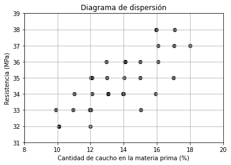

```
El coeficiente de correlacion: 0.764
Existe una correlación positiva entre la cantidad de caucho y la resistencia
```

```python
# Data
x = df['x']
y = df['y']

jitter_strength = 0.1
x_jittered = x + np.random.uniform(-jitter_strength, jitter_strength, size=len(x))
y_jittered = y + np.random.uniform(-jitter_strength, jitter_strength, size=len(y))

# Elabora un Diagrama de dispersión
plt.scatter(x_jittered, y,color='black', alpha=0.7)
plt.xlim(8,20)
plt.ylim(31,39)
plt.xlabel('Cantidad de caucho en la materia prima (%)')
plt.ylabel('Resistencia (MPa)')
plt.title('Diagrama de dispersión')
plt.grid(True)
plt.show()

# Calcula el coeficiente de correlación entre x e y
correlation_coefficient = np.corrcoef(x, y)[0, 1]
print(f'El coeficiente de correlacion: {correlation_coefficient:.3f}')
print("Existe una correlación positiva entre la cantidad de caucho y la resistencia")
```

## 7.2

図7.3(a)-(f)に示す６つの散布図について、相関係数を計算せよ。

Calcule el coeficiente de correlación para los seis diagramas de dispersión mostrados en la Figuras 7.3 (a)-(f)

```python
sheet = client.open_by_key(SPREADSHEET_ID).worksheet("Sheet20") # 最初のシートを取得

# データを取得
list_of_lists = sheet.get_all_records()
df = pd.DataFrame(list_of_lists)

df = df.set_index('No')
df = df.applymap(lambda x: pd.to_numeric(x, errors="coerce"))
```

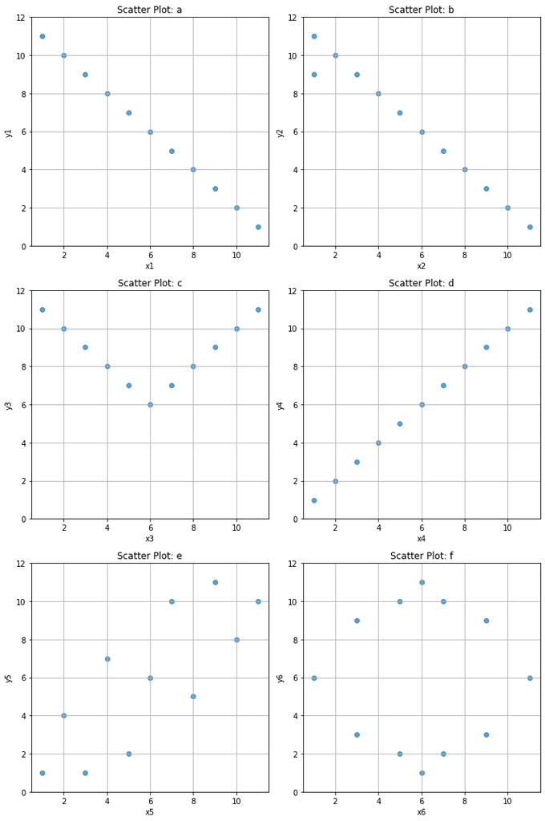

```python
fig, axes = plt.subplots(3, 2, figsize=(10, 15))
pairs = [("x1", "y1"), ("x2", "y2"), ("x3", "y3"), ("x4", "y4"), ("x5", "y5"), ("x6", "y6")]

i = 0
for ax, (x_col, y_col) in zip(axes.flatten(), pairs):
    ax.scatter(df[x_col], df[y_col], alpha=0.7)
    ax.set_ylim(0, 12)
    ax.set_xlabel(x_col)
    ax.set_ylabel(y_col)
    alpha = chr(ord("a")+i)
    ax.set_title(f"Scatter Plot: {alpha}")
    ax.grid(True)
    i = i+1

plt.tight_layout()
plt.show()
```

```python
# Calcule el coeficiente de correlación
i = 0
correlations = {pair: df[pair[0]].corr(df[pair[1]]) for pair in pairs}
for pair, corr in correlations.items():
    alpha = chr(ord("a")+i)
    print(f"Correlatión {alpha}: {corr:.2f}")
    i = i+1
```

[output not shown]

## Por favor, responda a las preguntas del examen de práctica a través del siguiente enlace.

[Simulacro de examen](https://forms.gle/87TeMCx7SS9wUBDL8)

## 12.1

図１２．１は $ (x_1, y_1), (x_2, y_2) $ それぞれ２０個の散布図である。

La Figura 12.1 muestra un diagrama de dispersión con 20 puntos para cada par $ (x_1, y_1), (x_2, y_2) $

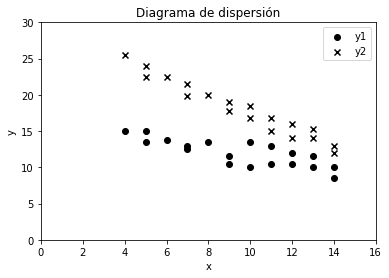

```python
SPREADSHEET_ID = "1W4H3VxXJwpKGMu0rE9ocz6yA6J0boG9vGzktgsro1es"
sheet = client.open_by_key(SPREADSHEET_ID).worksheet("Sheet1") # 最初のシートを取得

# データを取得
list_of_lists = sheet.get_all_values()
df = pd.DataFrame(list_of_lists)

df.reset_index(drop=True, inplace=True)

data1 = df.iloc[1:20,0:2].values
floatArray = np.asarray(data1, dtype=float)
df1 = pd.DataFrame(floatArray, columns=["x1","y1"])

x1 = df1["x1"]
y1 = df1["y1"]
data2 = df.iloc[1:20,2:4].values

floatArray = np.asarray(data2, dtype=float)
df2 = pd.DataFrame(floatArray, columns=["x2","y2"])

x2 = df2["x2"]
y2 = df2["y2"]

plt.scatter(x1,y1, color='k', label='y1' )
plt.scatter(x2,y2, marker='x', color='k', label="y2")
plt.ylim(0,30.0)
plt.xlim(0,16.0)
plt.ylabel('y')
plt.xlabel('x')
plt.title('Diagrama de dispersión')
plt.legend()

plt.savefig('Graph3/scatter12-1.png', dpi=300)  # 300 dpiで保存
```

40個の対の全データの相関係数、(x1, y1)、(x2, y2)の相関係数を求めよ。

Calcule el coeficiente de correlación para todos de los 40 pares, así como el coeficiente de correlación para los pares $ (x_1, y_1) $ y $ (x_2, y_2) $.

```python
# Correlacion para todos de los 40 pares
x = pd.concat([x1,x2])
y = pd.concat([y1,y2])
res = x.corr(y)

# Correlacion para x1, y1
res1 = x1.corr(y1)

# Correlacion para x2, y2
res2 = x2.corr(y2)

print(f'correlación para todos de los 40 pares: {res:.3f}')
print(f'correcelación para (x1, y1): {res1:.3f}')
print(f'correlacionres para (x2, y2): {res2:.3f}')
```

[output not shown]

## 12.2

表12.1のあるお店の来客数と、売り上げデータから相関係数を求めよ。

Calcule el coeficiente de correlación a partir de los datos de la cantidad de clientes y las ventas de una tienda en la Tabla 12.1

```python
sheet = client.open_by_key(SPREADSHEET_ID).worksheet("Sheet2") # 最初のシートを取得

# データを取得
list_of_lists = sheet.get_all_values()
df = pd.DataFrame(list_of_lists)

data1 = df.iloc[1:,1:].values

df = df.T
df.columns = df.iloc[0]
df = df.drop(df.index[0])
df = df.drop(df.columns[0], axis=1)
df.index = ["clientes", "ventas"]
df = df.astype(int)

print("Tabla 12.1 Los Datos de la cantidad de clientes y las ventas")
df
```

```
Tabla 12.1 Los Datos de la cantidad de clientes y las ventas
```

|  | 1 | 2 | 3 | 4 | 5 | 6 | 7 | 8 | 9 | 10 | 11 | 12 | 13 | 14 | 15 | 16 | 17 | 18 | 19 | 20 |
| --- | --- | --- | --- | --- | --- | --- | --- | --- | --- | --- | --- | --- | --- | --- | --- | --- | --- | --- | --- | --- |
| clientes | 29 | 32 | 29 | 28 | 25 | 28 | 31 | 31 | 32 | 23 | 29 | 32 | 27 | 30 | 29 | 29 | 30 | 30 | 32 | 29 |
| ventas | 50 | 49 | 46 | 51 | 44 | 46 | 52 | 52 | 51 | 42 | 46 | 52 | 47 | 53 | 51 | 51 | 53 | 53 | 54 | 47 |

[output not shown]

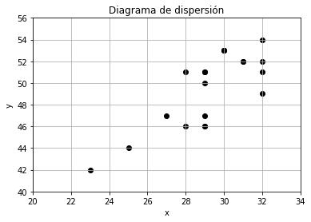

```python
df1 = pd.DataFrame(data1, columns=["x","y"])
df1 = df1.astype(float)

x = df1["x"]
y = df1["y"]
plt.scatter(x,y, color='k' )
plt.ylim(40,56.0)
plt.xlim(20,34.0)
plt.ylabel('y')
plt.xlabel('x')
plt.title('Diagrama de dispersión')
plt.grid()

plt.savefig('Graph3/scatter12-2.png', dpi=300)

res = x.corr(y)
print(f'Coeficiente de correlación: {res:.3f}')
```

```python
notebook_name = 'QCKentei3-7.ipynb'
notebook_name_html = notebook_name.replace(".ipynb",".html")

!jupyter nbconvert --to html {notebook_name}
```

```
[NbConvertApp] Converting notebook QCKentei3-7.ipynb to html
[NbConvertApp] Writing 696553 bytes to QCKentei3-7.html
```